# 10_1_Numpy-Clase slides

### 13.1 Aritmética

- Suma `**sum**`

Es importante enfatizar en la importancia de saber sobre qué eje ( *axis* ) de los arrays queremos realizar la suma.

```python
e = np.array([[[1, 0], [0, 0]],
              [[1, 1], [1, 0]],
              [[1, 0], [0, 1]]]
            )

print(e)
e.sum(axis = 0)
```

El resultado significa que sumando las columnas del primer componente que es:

[1. 0]

[1, 1]

[1, 0]

Obtenemos que las filas en la columna suman 3 y en la segunda columna 1, por lo tanto [3, 1]

En el segundo componente que es:

[0, 0]

[1, 0]

[0, 1]

Obtenemos que las filas de la primera columna suman 1 y de la segunda 1 también, por lo tanto [1, 1]

```python
e.sum(axis=1)
```

En este caso cada dimensión, funciona a nivel de fila, por lo tanto, si sumamos la primera fila que sería [1 + 0], [0 + 0] = [1, 0]

La segunda fila: [1 + 1], [1 + 0] = [2, 1]

La tercera: [1 + 0], [0 + 1] = [1, 1]

Si no especificamos su eje, se calcula de forma global.

```python
e.sum()
```

```python
print('Filas ', e.sum(axis=0))
print('Columnas ', e.sum(axis=1))
print('Total ', e.sum())
```

- `**round**`: **Permite redondear a n decimales todo un array.**

```python
rand = np.random.rand(10)
print(rand)
rand.round(2)
```

- `**fill**`: **Permite rellenar un array con un valor pasado por parámetro.**

```python
zero_array = np.zeros(20)#creamos un array 1D de 20 ceros
print(zero_array)
zero_array[5:15].fill(5)#rellenamos las posiciones 5-14 con cincos.
zero_array
```

- **Suma elemento a elemento de un array.**

**Sumamos el mismo array**

```python
arr = np.arange(0,10) # crear un array de 10 elementos
arr
```

```python
arr + arr # Suma elemento a elemento de los arrays
```

**Sumamos dos arrays 1D de distinto tamaño**

```python
# Suma de valores uno a uno con arrays
aa = np.arange(5)
print(aa)
bb = np.arange(10) # este array es mas grande que el anterior
print(bb)
aa+bb[:5] # deben tener el mismo tamaño para realizar la suma
```

**Sumamos Arrays 2D**

```python
data = np.array([[1, 2], [3, 4]])
ones = np.array([[1, 1], [1, 1]])
data + ones
```

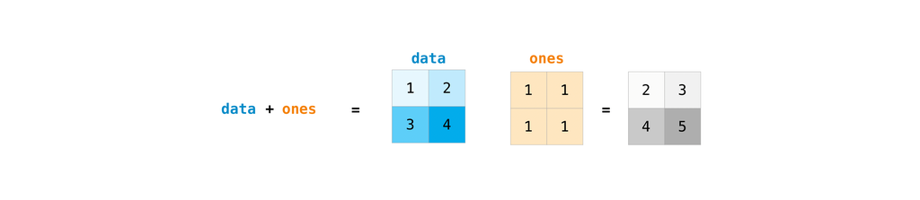

Puedes realizar estas operaciones aritméticas en matrices de diferentes tamaños, pero **solo si una matriz tiene solo una columna o una fila.**

```python
data = np.array([[1, 2], [3, 4], [5, 6]])
ones_row = np.array([[1, 1]])
data + ones_row
```

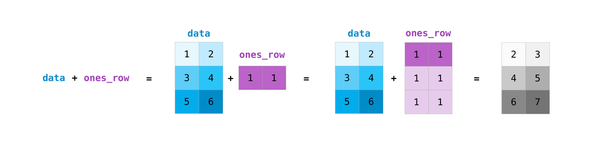

- **Multiplicacion elemento a elemento**

```python
arr * arr
```

- **Resta elemento a elemento**

```python
arr - arr
```

- **División elemento a elemento**

```python
# Mensaje de advertencia si se presenta una division por cero, pero no hay error!
# solo se reemplazo por el valor nan
arr/arr # division elemento a elemento
```

- **Raiz cuadrada de cada elemento**

```python
#Calcular la raiz cuadrada de cada elemento
np.sqrt(arr)
```

- **Valor absoluto de cada elemento**

```python
np.abs(arr)
```

### 13.2 Estadística

- **Desviacion estandar**

En estadística, la desviación típica (también conocida como desviación estándar y desvío típico y representada de manera abreviada por la letra griega minúscula **gma σ o la letra latina s, así como por las siglas SD (de standard deviation).**

- **Es una medida que se utiliza para cuantificar la variación o la dispersión de un conjunto de datos numéricos.1**
- **Una desviación estándar baja** indica que la mayor parte de los datos de una muestra **tienden a estar agrupados cerca de su media** (también denominada el valor esperado), mientras que una **desviación estándar alta** indica que los datos se extienden sobre un **rango de valores más amplio.**

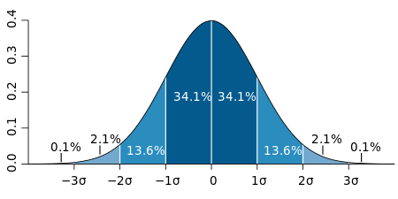

```python
# Desviacion estandar
np.std(arr)# en este caso vemos que tiene una desviación elevada, casi de 3, alejandose mucho de su media.
```

- **Media** - `**mean**`:

Realiza la media del array o por uno de sus ejes.

```python
e
```

```python
e.mean(axis = 0)
```

```python
e.mean(axis = 1)
```

```python
e.mean()#la media de todo el array
```

```python
arr.mean()
```

- **Mediana** - `median`:

En el ámbito de la estadística, la mediana representa el valor de la variable de posición central en un conjunto de datos ordenados. Se le denota mediana.

Si la serie tiene un número par de puntuaciones, la mediana es la media entre las dos puntuaciones centrales.

Ejemplo.

7, 8, 9, 10, 11, 12

Mediana = 9,5 = (9+10)/2

```python
print(arr)
np.median(arr)
```

- **Varianza** - `var`:

La varianza es una **medida de dispersión** que representa la **variabilidad de una serie de datos respecto a su media.**

```python
np.var(arr)
```

### 13.3 Operaciones de Matrices

```python
#creacion de una matriz de ejemplo
arr_2d = np.array(([5,10,15],[20,25,30],[35,40,45]))
arr_2d
```

- **Trasponer una Matriz**

Las matrices NumPy tienen la propiedad Tque le permite transponer una matriz.

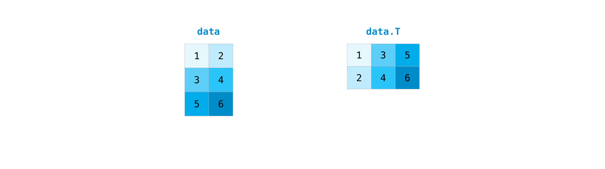

```python
# transpuesta de una matriz
arr_2d.T # tambien puede ser arr_2d.transpose()
```

- **Inversa de una matriz**

La función de NumPy nos **np.flip()** permite voltear o invertir el contenido de una matriz a lo largo de un eje. Cuando usemos np.flip(), hay que especificar la matriz que le gustaría invertir y el eje. Si no se especifica el eje, NumPy invertirá el contenido a lo largo de todos los ejes de la matriz de entrada.

```python
#Array 1D
arr = np.array([1, 2, 3, 4, 5, 6, 7, 8])
reversed_arr = np.flip(arr)
print(reversed_arr)
```

Invertimos todos son ejes

```python
#Array 2D
arr_2d = np.array([[1, 2, 3, 4], [5, 6, 7, 8], [9, 10, 11, 12]])
print(arr_2d)
reversed_arr = np.flip(arr_2d)
print(reversed_arr)
#no hemos especificado ejes y ha invertido los valores en todos los ejes
#primero invierte las filas y de ese resultado invierte las columnas.
```

Invertimos solo las filas

```python
reversed_arr_rows = np.flip(arr_2d, axis=0)
print(reversed_arr_rows)
```

Invertir solo las columnas con:

```python
reversed_arr_columns = np.flip(arr_2d, axis=1)
print(reversed_arr_columns)
```

También podemeos invertir el contenido de una sola columna o fila. Por ejemplo, puede invertir el contenido de la fila en la posición de índice 1 (la segunda fila):

```python
arr_2d[1] = np.flip(arr_2d[1])
print(arr_2d)

#es equivalente a:
fila1_inversa = arr_2d[1, ::-1]
print(fila1_inversa)
```

También podemos invertir la columna en la posición de índice 1 (la segunda columna):

```python
print(arr_2d)
arr_2d[:,1] = np.flip(arr_2d[:,1])
print(arr_2d)

#es equivalente a:
columna1_inversa = arr_2d[::-1, 1]
print(columna1_inversa)
```

### EJERCICIOS

[figure not shown]

### Ejercicio 1

Crea un Array 2D de 25 números aleatorios entre los 100 primeros números.

1) Pinta la matriz resultante.

2) De la matriz generada, quedate con los valores que sean múltiplos de 5.

3) Quedate con todos los valores pares o impares menores de 10.

4) Quedate con los valores que sean multiplos de 3 y que sean impares mayores de 20.

5) Une todos los resultados de los apartados 2-4 en un nuevo array 1D quedandote solo con los valores únicos.

6) Reestructura el array para convertirlo en uno 2D con tantas filas como elementos tenga.

7) Del nuevo array 2D, muestra su estructura, dimensiones y número de elementos

```python
#1)
```

```python
#)2 multipos de 5
```

```python
#3) pares mejores de 10
```

```python
#4) multiplos de 3 o que sean impares mayores de 20.
```

```python
#5) Une todos los resultados de los apartados 2-4 en un nuevo array 1D quedandote solo con los valores únicos.
```

```python
#6) Reestructura el array para convertirlo en uno 2D con tantas filas como elementos tenga.
```

```python
#7 Del nuevo array 2D, muestra su estructura, dimensiones y número de elementos
```

### Ejercicio 2

Escribe un programa que genere una matriz de 10x10, en la que sus elementos en los bordes sean 1 y sus elementos interiores sean 0.

#### Solución

### Ejercicio 3

Escribe una función que reciba un array de valores para convertir los valores de grados centígrados en grados Fahrenheit y viceversa.

Arrays de pruebas:

**Valores en grados Fahrenheit [0, 12, 45.21, 34, 99.91]**

**Valores en grados Centígrados [-17.78, -11.11, 7.34, 1.11, 37.73, 0. ]**

La formula para convertir unos grados en otros es:

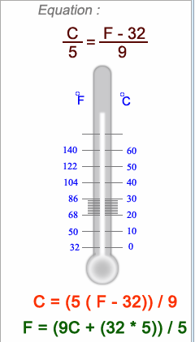

Elabora un programa de pruebas que pregunte al usuario la conversión que quiere realizar y en función de ello cargue un array de temperaturas u otro.

```python
#define aquí la función
```

### Ejercicio 4

1. Crea los siguientes Arrays:
   - a será un array 2D con valores aleatorios normales y estructura 3x3.
   - b será un array 1D con 3 elementos aletarorios entre 3-6.
2. Suma los dos arrays y al resultado aplicale la raiz cuadrada.
3. Redondea el array resultante a dos decimales.
4. Crea un array denominado c que sea 2D 5x5 con números aleatorios entre 0-60.
5. Ordena cada fila.
6. Aplica la inversa:
   - A cada fila del array resultante del apartado 5.
   - A cada columna.
   - A toda la matriz
7. Saca la matriz traspuesta de c.

```python
#1)
```

```python
#2)
```

```python
#3 redondeamos toda la matriz a 2 decimales
```

```python
#4)Crea un array denominado c que sea 2D 5x5 con números aleatorios entre 0-60.
```

```python
#5)Ordena cada fila.
```

```python
#6
'''Aplica la inversa:

A cada fila del array resultante del apartado 5.
A cada columna.
A toda la matriz'''
```

```python
#7) Saca la matriz traspuesta de c.
```

### Ejercicio 5

Escribe una función para encontrar la unión de dos arrays 1D.

La unión devolverá la matriz única y ordenada de valores que se encuentran en cualquiera de los dos arrays de entrada.

La función recibirá 2 parámetros con los arrays y retornará un nuevo array con la unión de ambos.

Antes de realizar cualquier operación se comprobará que los dos arrays tienen la misma dimensión, en caso de no ser así, aplanarán para convertirlos en 1D.